# Project Movie Lens - Submitted by Krishna Josyula

### Project - MovieLens Data Analysis By Krishna Josyula

The GroupLens Research Project is a research group in the Department of Computer Science and Engineering at the University of Minnesota. The data is widely used for collaborative filtering and other filtering solutions. However, we will be using this data to act as a means to demonstrate our skill in using Python to “play” with data.

### Datasets Information:

- Data.csv: It contains information of ratings given by the users to a particular movie. Columns: user id, movie id, rating, timestamp
- item.csv: File contains information related to the movies and its genre.
- Columns: movie id, movie title, release date, unknown, Action, Adventure, Animation, Children’s, Comedy, Crime, Documentary, Drama, Fantasy, Film-Noir, Horror, Musical, Mystery, Romance, Sci-Fi, Thriller, War, Western
- user.csv: It contains information of the users who have rated the movies. Columns: user id, age, gender, occupation, zip code

### Objective:

`To implement the techniques learnt as a part of the course.`

### Learning Outcomes:

- Exploratory Data Analysis
- Visualization using Python
- Pandas – groupby, merging

#### Domain

`Internet and Entertainment`

**Note that the project will need you to apply the concepts of groupby and merging extensively.**

#### 1. Import the packages - 2.5 marks

```python
import warnings
```

```python
from scipy.stats import zscore
from sklearn.preprocessing import StandardScaler, MinMaxScaler
```

```python
import numpy as np
import pandas as pd
import matplotlib.pyplot as plt
import seaborn as sns
```

#### 2. Read the 3 datasets into dataframes - 2.5 marks

```python
dfrating=pd.read_csv('Data.csv')
```

```python
dfmovie=pd.read_csv('item.csv')
```

```python
dfuser=pd.read_csv('user.csv')
```

#### 3. Apply info, shape, describe, and find the number of missing values in the data - 5 marks

- Note that you will need to do it for all the three datasets seperately

```python
dfrating.shape
```

```
(100000, 4)
```

```python
dfrating.describe().T
```

|  | count | mean | std | min | 25% | 50% | 75% | max |
| --- | --- | --- | --- | --- | --- | --- | --- | --- |
| user id | 100000.0 | 4.624848e+02 | 2.666144e+02 | 1.0 | 254.0 | 447.0 | 682.0 | 943.0 |
| movie id | 100000.0 | 4.255301e+02 | 3.307984e+02 | 1.0 | 175.0 | 322.0 | 631.0 | 1682.0 |
| rating | 100000.0 | 3.529860e+00 | 1.125674e+00 | 1.0 | 3.0 | 4.0 | 4.0 | 5.0 |
| timestamp | 100000.0 | 8.835289e+08 | 5.343856e+06 | 874724710.0 | 879448709.5 | 882826944.0 | 888259984.0 | 893286638.0 |

```python
dfmovie.shape
```

```
(1681, 22)
```

```python
dfmovie.describe().T
```

|  | count | mean | std | min | 25% | 50% | 75% | max |
| --- | --- | --- | --- | --- | --- | --- | --- | --- |
| movie id | 1681.0 | 841.841761 | 485.638077 | 1.0 | 422.0 | 842.0 | 1262.0 | 1682.0 |
| unknown | 1681.0 | 0.000595 | 0.024390 | 0.0 | 0.0 | 0.0 | 0.0 | 1.0 |
| Action | 1681.0 | 0.149316 | 0.356506 | 0.0 | 0.0 | 0.0 | 0.0 | 1.0 |
| Adventure | 1681.0 | 0.080309 | 0.271852 | 0.0 | 0.0 | 0.0 | 0.0 | 1.0 |
| Animation | 1681.0 | 0.024985 | 0.156126 | 0.0 | 0.0 | 0.0 | 0.0 | 1.0 |
| Childrens | 1681.0 | 0.072576 | 0.259516 | 0.0 | 0.0 | 0.0 | 0.0 | 1.0 |
| Comedy | 1681.0 | 0.300416 | 0.458576 | 0.0 | 0.0 | 0.0 | 1.0 | 1.0 |
| Crime | 1681.0 | 0.064842 | 0.246321 | 0.0 | 0.0 | 0.0 | 0.0 | 1.0 |
| Documentary | 1681.0 | 0.029744 | 0.169931 | 0.0 | 0.0 | 0.0 | 0.0 | 1.0 |
| Drama | 1681.0 | 0.431291 | 0.495404 | 0.0 | 0.0 | 0.0 | 1.0 | 1.0 |
| Fantasy | 1681.0 | 0.013087 | 0.113683 | 0.0 | 0.0 | 0.0 | 0.0 | 1.0 |
| Film-Noir | 1681.0 | 0.014277 | 0.118667 | 0.0 | 0.0 | 0.0 | 0.0 | 1.0 |
| Horror | 1681.0 | 0.054729 | 0.227519 | 0.0 | 0.0 | 0.0 | 0.0 | 1.0 |
| Musical | 1681.0 | 0.033314 | 0.179507 | 0.0 | 0.0 | 0.0 | 0.0 | 1.0 |
| Mystery | 1681.0 | 0.036288 | 0.187061 | 0.0 | 0.0 | 0.0 | 0.0 | 1.0 |
| Romance | 1681.0 | 0.146936 | 0.354148 | 0.0 | 0.0 | 0.0 | 0.0 | 1.0 |
| Sci-Fi | 1681.0 | 0.060083 | 0.237712 | 0.0 | 0.0 | 0.0 | 0.0 | 1.0 |
| Thriller | 1681.0 | 0.149316 | 0.356506 | 0.0 | 0.0 | 0.0 | 0.0 | 1.0 |
| War | 1681.0 | 0.042237 | 0.201189 | 0.0 | 0.0 | 0.0 | 0.0 | 1.0 |
| Western | 1681.0 | 0.016062 | 0.125751 | 0.0 | 0.0 | 0.0 | 0.0 | 1.0 |

```python
dfmovie.info()
```

```
<class 'pandas.core.frame.DataFrame'>
RangeIndex: 1681 entries, 0 to 1680
Data columns (total 22 columns):
 #   Column        Non-Null Count  Dtype
---  ------        --------------  -----
 0   movie id      1681 non-null   int64
 1   movie title   1681 non-null   object
 2   release date  1681 non-null   object
 3   unknown       1681 non-null   int64
 4   Action        1681 non-null   int64
 5   Adventure     1681 non-null   int64
 6   Animation     1681 non-null   int64
 7   Childrens     1681 non-null   int64
 8   Comedy        1681 non-null   int64
 9   Crime         1681 non-null   int64
 10  Documentary   1681 non-null   int64
 11  Drama         1681 non-null   int64
 12  Fantasy       1681 non-null   int64
 13  Film-Noir     1681 non-null   int64
 14  Horror        1681 non-null   int64
 15  Musical       1681 non-null   int64
 16  Mystery       1681 non-null   int64
 17  Romance       1681 non-null   int64
 18  Sci-Fi        1681 non-null   int64
 19  Thriller      1681 non-null   int64
 20  War           1681 non-null   int64
 21  Western       1681 non-null   int64
dtypes: int64(20), object(2)
memory usage: 289.0+ KB
```

```python
dfuser.shape
```

```
(943, 5)
```

```python
dfuser.describe().T
```

|  | count | mean | std | min | 25% | 50% | 75% | max |
| --- | --- | --- | --- | --- | --- | --- | --- | --- |
| user id | 943.0 | 472.000000 | 272.364951 | 1.0 | 236.5 | 472.0 | 707.5 | 943.0 |
| age | 943.0 | 34.051962 | 12.192740 | 7.0 | 25.0 | 31.0 | 43.0 | 73.0 |

```python
dfuser.info()
```

```
<class 'pandas.core.frame.DataFrame'>
RangeIndex: 943 entries, 0 to 942
Data columns (total 5 columns):
 #   Column      Non-Null Count  Dtype
---  ------      --------------  -----
 0   user id     943 non-null    int64
 1   age         943 non-null    int64
 2   gender      943 non-null    object
 3   occupation  943 non-null    object
 4   zip code    943 non-null    object
dtypes: int64(2), object(3)
memory usage: 37.0+ KB
```

#### 4. Find the number of movies per genre using the item data - 2.5 marks

```python
dfmovie.info()
```

```
<class 'pandas.core.frame.DataFrame'>
RangeIndex: 1681 entries, 0 to 1680
Data columns (total 22 columns):
 #   Column        Non-Null Count  Dtype
---  ------        --------------  -----
 0   movie id      1681 non-null   int64
 1   movie title   1681 non-null   object
 2   release date  1681 non-null   object
 3   unknown       1681 non-null   int64
 4   Action        1681 non-null   int64
 5   Adventure     1681 non-null   int64
 6   Animation     1681 non-null   int64
 7   Childrens     1681 non-null   int64
 8   Comedy        1681 non-null   int64
 9   Crime         1681 non-null   int64
 10  Documentary   1681 non-null   int64
 11  Drama         1681 non-null   int64
 12  Fantasy       1681 non-null   int64
 13  Film-Noir     1681 non-null   int64
 14  Horror        1681 non-null   int64
 15  Musical       1681 non-null   int64
 16  Mystery       1681 non-null   int64
 17  Romance       1681 non-null   int64
 18  Sci-Fi        1681 non-null   int64
 19  Thriller      1681 non-null   int64
 20  War           1681 non-null   int64
 21  Western       1681 non-null   int64
dtypes: int64(20), object(2)
memory usage: 289.0+ KB
```

```python
##The consolidated number of moviews per genre is calculated below:
# use sum on the default axis
#dfmovie.sum()
dfmovie.sum(axis = 0, skipna = True)
```

```
movie id                                                  1415136
movie title     Toy Story GoldenEye Four Rooms Get Shorty Copy...
release date    01-Jan-199501-Jan-199501-Jan-199501-Jan-199501...
unknown                                                         1
Action                                                        251
Adventure                                                     135
Animation                                                      42
Childrens                                                     122
Comedy                                                        505
Crime                                                         109
Documentary                                                    50
Drama                                                         725
Fantasy                                                        22
Film-Noir                                                      24
Horror                                                         92
Musical                                                        56
Mystery                                                        61
Romance                                                       247
Sci-Fi                                                        101
Thriller                                                      251
War                                                            71
Western                                                        27
dtype: object
```

#### 5. Find the movies that have more than one genre - 5 marks

```python
#hint: use sum on the axis = 1 #df['total'] = df.sum(axis=1)
dfgenre=dfmovie.drop(['movie id'], axis=1) #dropping movie id to avoid it in summation of genres the movie belomgs to
column_list=list(dfgenre)
dfgenre["Total"]=dfgenre[column_list].sum(axis=1,skipna=True)
dfgenre=dfgenre[dfgenre["Total"]>=2] ## Here, we are finding those genre of movies that have more than 1 in the given data.
dfgenre[["movie title","Total"]]
```

|  | movie title | Total |
| --- | --- | --- |
| 0 | Toy Story | 3 |
| 1 | GoldenEye | 3 |
| 3 | Get Shorty | 3 |
| 4 | Copycat | 3 |
| 6 | Twelve Monkeys | 2 |
| ... | ... | ... |
| 1667 | MURDER and murder | 3 |
| 1668 | Tainted | 2 |
| 1671 | Mirage | 2 |
| 1677 | B. Monkey | 2 |
| 1678 | Sliding Doors | 2 |

849 rows × 2 columns

#### 6. Drop the movie where the genre is unknown - 2.5 marks

```python
dfknown=dfmovie[dfmovie["unknown"]==1] # Here a new dataframe dfknown is created which has the movie(s) on unknown gene
dfknown
```

|  | movie id | movie title | release date | unknown | Action | Adventure | Animation | Childrens | Comedy | Crime | ... | Fantasy | Film-Noir | Horror | Musical | Mystery | Romance | Sci-Fi | Thriller | War | Western |
| --- | --- | --- | --- | --- | --- | --- | --- | --- | --- | --- | --- | --- | --- | --- | --- | --- | --- | --- | --- | --- | --- |
| 1371 | 1373 | Good Morning | 4-Feb-1971 | 1 | 0 | 0 | 0 | 0 | 0 | 0 | ... | 0 | 0 | 0 | 0 | 0 | 0 | 0 | 0 | 0 | 0 |

1 rows × 22 columns

```python
dfmovie.shape # The number of rows in dfmovie dataframe i.e. in the date of movies is 1681 row as can be seen below:
```

```
(1681, 22)
```

```python
# Dropping the row which has the moie categorized as "uknown":
indexNames=dfmovie[dfmovie['unknown']==1].index
dfmovie.drop(indexNames, inplace=True)
```

```python
# We will validate that the row has been dropped
dfmovie.shape
```

```
(1680, 22)
```

```python
# HINT: Use distplot for age and countplot for gender,ratings,occupation. Use lineplot or countplot for release year.
# HINT: Please refer to the below snippet to understand how to get to release year from release date. You can use str.split()
# as depicted below.as depicted below or you could convert it to pandas datetime format and extract year (.dt.year)
```

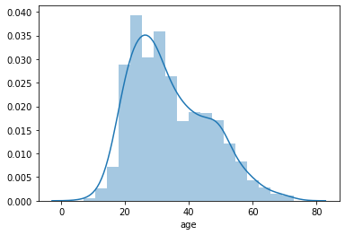

```python
#your answers here
sns.distplot(dfuser['age'])
```

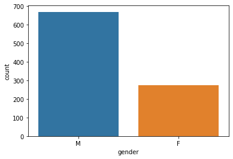

```python
sns.countplot(dfuser['gender'])
```

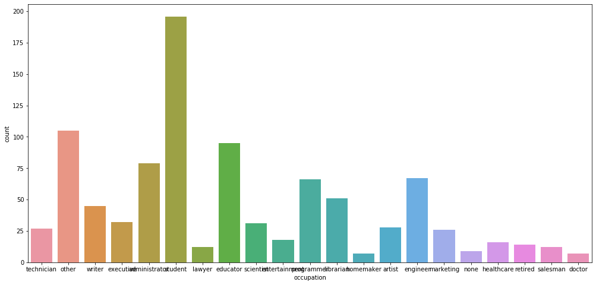

```python
plt.figure(figsize=(17,8))
sns.countplot(dfuser['occupation'])
```

```python
#Here the 'Release year' is derived based on the 'Release date':
#dfmovie['release date']=pd.to_datetime(dfmovie['release date']) #While used the second query, hav retained this query as well
#dfmovie['release year']=dfmovie['release date'].dt.year

dfmovie["release date"]=pd.DatetimeIndex(dfmovie["release date"])
dfmovie["release year"]=dfmovie["release date"].map(lambda x: x.year)
dfmovie
```

|  | movie id | movie title | release date | unknown | Action | Adventure | Animation | Childrens | Comedy | Crime | ... | Film-Noir | Horror | Musical | Mystery | Romance | Sci-Fi | Thriller | War | Western | release year |
| --- | --- | --- | --- | --- | --- | --- | --- | --- | --- | --- | --- | --- | --- | --- | --- | --- | --- | --- | --- | --- | --- |
| 0 | 1 | Toy Story | 1995-01-01 | 0 | 0 | 0 | 1 | 1 | 1 | 0 | ... | 0 | 0 | 0 | 0 | 0 | 0 | 0 | 0 | 0 | 1995 |
| 1 | 2 | GoldenEye | 1995-01-01 | 0 | 1 | 1 | 0 | 0 | 0 | 0 | ... | 0 | 0 | 0 | 0 | 0 | 0 | 1 | 0 | 0 | 1995 |
| 2 | 3 | Four Rooms | 1995-01-01 | 0 | 0 | 0 | 0 | 0 | 0 | 0 | ... | 0 | 0 | 0 | 0 | 0 | 0 | 1 | 0 | 0 | 1995 |
| 3 | 4 | Get Shorty | 1995-01-01 | 0 | 1 | 0 | 0 | 0 | 1 | 0 | ... | 0 | 0 | 0 | 0 | 0 | 0 | 0 | 0 | 0 | 1995 |
| 4 | 5 | Copycat | 1995-01-01 | 0 | 0 | 0 | 0 | 0 | 0 | 1 | ... | 0 | 0 | 0 | 0 | 0 | 0 | 1 | 0 | 0 | 1995 |
| ... | ... | ... | ... | ... | ... | ... | ... | ... | ... | ... | ... | ... | ... | ... | ... | ... | ... | ... | ... | ... | ... |
| 1676 | 1678 | Mat' i syn | 1998-02-06 | 0 | 0 | 0 | 0 | 0 | 0 | 0 | ... | 0 | 0 | 0 | 0 | 0 | 0 | 0 | 0 | 0 | 1998 |
| 1677 | 1679 | B. Monkey | 1998-02-06 | 0 | 0 | 0 | 0 | 0 | 0 | 0 | ... | 0 | 0 | 0 | 0 | 1 | 0 | 1 | 0 | 0 | 1998 |
| 1678 | 1680 | Sliding Doors | 1998-01-01 | 0 | 0 | 0 | 0 | 0 | 0 | 0 | ... | 0 | 0 | 0 | 0 | 1 | 0 | 0 | 0 | 0 | 1998 |
| 1679 | 1681 | You So Crazy | 1994-01-01 | 0 | 0 | 0 | 0 | 0 | 1 | 0 | ... | 0 | 0 | 0 | 0 | 0 | 0 | 0 | 0 | 0 | 1994 |
| 1680 | 1682 | Scream of Stone (Schrei aus Stein) | 1996-03-08 | 0 | 0 | 0 | 0 | 0 | 0 | 0 | ... | 0 | 0 | 0 | 0 | 0 | 0 | 0 | 0 | 0 | 1996 |

1680 rows × 23 columns

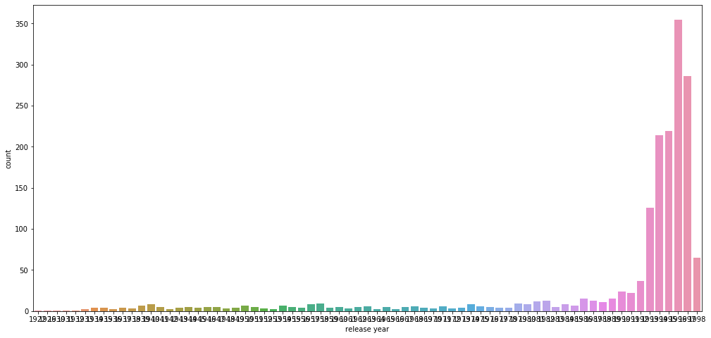

```python
plt.figure(figsize=(17,8))
sns.countplot(dfmovie['release year'])
```

### 8. Visualize how popularity of genres has changed over the years - 10 marks

Note that you need to use the number of releases in a year as a parameter of popularity of a genre

Hint

1: you need to reach to a data frame where the release year is the index and the genre is the column names (one cell shows the number of release in a year in one genre) or vice versa. Once that is achieved, you can either use multiple bivariate plots or can use the heatmap to visualise all the changes over the years in one go.

Hint 2: Use groupby on the relevant column and use sum() on the same to find out the nuumber of releases in a year/genre.

```python
dfmovie["release date"]=pd.DatetimeIndex(dfmovie["release date"])
dfmovie["release year"]=dfmovie["release date"].map(lambda x: x.year)
dfmovie
```

|  | movie id | movie title | release date | unknown | Action | Adventure | Animation | Childrens | Comedy | Crime | ... | Film-Noir | Horror | Musical | Mystery | Romance | Sci-Fi | Thriller | War | Western | release year |
| --- | --- | --- | --- | --- | --- | --- | --- | --- | --- | --- | --- | --- | --- | --- | --- | --- | --- | --- | --- | --- | --- |
| 0 | 1 | Toy Story | 1995-01-01 | 0 | 0 | 0 | 1 | 1 | 1 | 0 | ... | 0 | 0 | 0 | 0 | 0 | 0 | 0 | 0 | 0 | 1995 |
| 1 | 2 | GoldenEye | 1995-01-01 | 0 | 1 | 1 | 0 | 0 | 0 | 0 | ... | 0 | 0 | 0 | 0 | 0 | 0 | 1 | 0 | 0 | 1995 |
| 2 | 3 | Four Rooms | 1995-01-01 | 0 | 0 | 0 | 0 | 0 | 0 | 0 | ... | 0 | 0 | 0 | 0 | 0 | 0 | 1 | 0 | 0 | 1995 |
| 3 | 4 | Get Shorty | 1995-01-01 | 0 | 1 | 0 | 0 | 0 | 1 | 0 | ... | 0 | 0 | 0 | 0 | 0 | 0 | 0 | 0 | 0 | 1995 |
| 4 | 5 | Copycat | 1995-01-01 | 0 | 0 | 0 | 0 | 0 | 0 | 1 | ... | 0 | 0 | 0 | 0 | 0 | 0 | 1 | 0 | 0 | 1995 |
| ... | ... | ... | ... | ... | ... | ... | ... | ... | ... | ... | ... | ... | ... | ... | ... | ... | ... | ... | ... | ... | ... |
| 1676 | 1678 | Mat' i syn | 1998-02-06 | 0 | 0 | 0 | 0 | 0 | 0 | 0 | ... | 0 | 0 | 0 | 0 | 0 | 0 | 0 | 0 | 0 | 1998 |
| 1677 | 1679 | B. Monkey | 1998-02-06 | 0 | 0 | 0 | 0 | 0 | 0 | 0 | ... | 0 | 0 | 0 | 0 | 1 | 0 | 1 | 0 | 0 | 1998 |
| 1678 | 1680 | Sliding Doors | 1998-01-01 | 0 | 0 | 0 | 0 | 0 | 0 | 0 | ... | 0 | 0 | 0 | 0 | 1 | 0 | 0 | 0 | 0 | 1998 |
| 1679 | 1681 | You So Crazy | 1994-01-01 | 0 | 0 | 0 | 0 | 0 | 1 | 0 | ... | 0 | 0 | 0 | 0 | 0 | 0 | 0 | 0 | 0 | 1994 |
| 1680 | 1682 | Scream of Stone (Schrei aus Stein) | 1996-03-08 | 0 | 0 | 0 | 0 | 0 | 0 | 0 | ... | 0 | 0 | 0 | 0 | 0 | 0 | 0 | 0 | 0 | 1996 |

1680 rows × 23 columns

```python
dfmovie.set_index('release year')
```

| release year | movie id | movie title | release date | unknown | Action | Adventure | Animation | Childrens | Comedy | Crime | ... | Fantasy | Film-Noir | Horror | Musical | Mystery | Romance | Sci-Fi | Thriller | War | Western |
| --- | --- | --- | --- | --- | --- | --- | --- | --- | --- | --- | --- | --- | --- | --- | --- | --- | --- | --- | --- | --- | --- |
| 1995 | 1 | Toy Story | 1995-01-01 | 0 | 0 | 0 | 1 | 1 | 1 | 0 | ... | 0 | 0 | 0 | 0 | 0 | 0 | 0 | 0 | 0 | 0 |
| 1995 | 2 | GoldenEye | 1995-01-01 | 0 | 1 | 1 | 0 | 0 | 0 | 0 | ... | 0 | 0 | 0 | 0 | 0 | 0 | 0 | 1 | 0 | 0 |
| 1995 | 3 | Four Rooms | 1995-01-01 | 0 | 0 | 0 | 0 | 0 | 0 | 0 | ... | 0 | 0 | 0 | 0 | 0 | 0 | 0 | 1 | 0 | 0 |
| 1995 | 4 | Get Shorty | 1995-01-01 | 0 | 1 | 0 | 0 | 0 | 1 | 0 | ... | 0 | 0 | 0 | 0 | 0 | 0 | 0 | 0 | 0 | 0 |
| 1995 | 5 | Copycat | 1995-01-01 | 0 | 0 | 0 | 0 | 0 | 0 | 1 | ... | 0 | 0 | 0 | 0 | 0 | 0 | 0 | 1 | 0 | 0 |
| ... | ... | ... | ... | ... | ... | ... | ... | ... | ... | ... | ... | ... | ... | ... | ... | ... | ... | ... | ... | ... | ... |
| 1998 | 1678 | Mat' i syn | 1998-02-06 | 0 | 0 | 0 | 0 | 0 | 0 | 0 | ... | 0 | 0 | 0 | 0 | 0 | 0 | 0 | 0 | 0 | 0 |
| 1998 | 1679 | B. Monkey | 1998-02-06 | 0 | 0 | 0 | 0 | 0 | 0 | 0 | ... | 0 | 0 | 0 | 0 | 0 | 1 | 0 | 1 | 0 | 0 |
| 1998 | 1680 | Sliding Doors | 1998-01-01 | 0 | 0 | 0 | 0 | 0 | 0 | 0 | ... | 0 | 0 | 0 | 0 | 0 | 1 | 0 | 0 | 0 | 0 |
| 1994 | 1681 | You So Crazy | 1994-01-01 | 0 | 0 | 0 | 0 | 0 | 1 | 0 | ... | 0 | 0 | 0 | 0 | 0 | 0 | 0 | 0 | 0 | 0 |
| 1996 | 1682 | Scream of Stone (Schrei aus Stein) | 1996-03-08 | 0 | 0 | 0 | 0 | 0 | 0 | 0 | ... | 0 | 0 | 0 | 0 | 0 | 0 | 0 | 0 | 0 | 0 |

1680 rows × 22 columns

```python
#Grouping the movies for each realease year per the genre that movei has been marked to be belonging to:
dfannualmov=dfmovie.drop(['movie id'],axis=1)
dfannualmov=dfannualmov.groupby('release year').sum()
dfannualmov
```

| release year | unknown | Action | Adventure | Animation | Childrens | Comedy | Crime | Documentary | Drama | Fantasy | Film-Noir | Horror | Musical | Mystery | Romance | Sci-Fi | Thriller | War | Western |
| --- | --- | --- | --- | --- | --- | --- | --- | --- | --- | --- | --- | --- | --- | --- | --- | --- | --- | --- | --- |
| 1922 | 0 | 0 | 0 | 0 | 0 | 0 | 0 | 0 | 0 | 0 | 0 | 1 | 0 | 0 | 0 | 0 | 0 | 0 | 0 |
| 1926 | 0 | 0 | 0 | 0 | 0 | 0 | 0 | 0 | 1 | 0 | 0 | 0 | 0 | 0 | 0 | 0 | 0 | 0 | 0 |
| 1930 | 0 | 0 | 0 | 0 | 0 | 0 | 0 | 0 | 1 | 0 | 0 | 0 | 0 | 0 | 0 | 0 | 0 | 0 | 0 |
| 1931 | 0 | 0 | 0 | 0 | 0 | 0 | 1 | 0 | 0 | 0 | 1 | 0 | 0 | 0 | 0 | 0 | 1 | 0 | 0 |
| 1932 | 0 | 0 | 0 | 0 | 0 | 0 | 0 | 0 | 0 | 0 | 0 | 0 | 0 | 0 | 1 | 0 | 0 | 1 | 0 |
| ... | ... | ... | ... | ... | ... | ... | ... | ... | ... | ... | ... | ... | ... | ... | ... | ... | ... | ... | ... |
| 1994 | 0 | 30 | 13 | 4 | 15 | 82 | 8 | 9 | 97 | 3 | 0 | 8 | 2 | 2 | 35 | 7 | 25 | 7 | 6 |
| 1995 | 0 | 40 | 22 | 6 | 21 | 63 | 11 | 5 | 89 | 3 | 1 | 14 | 3 | 5 | 37 | 15 | 39 | 5 | 2 |
| 1996 | 0 | 44 | 24 | 9 | 21 | 108 | 21 | 18 | 170 | 6 | 1 | 11 | 9 | 6 | 38 | 15 | 47 | 9 | 2 |
| 1997 | 0 | 46 | 20 | 3 | 22 | 87 | 30 | 6 | 113 | 4 | 2 | 8 | 5 | 18 | 51 | 13 | 54 | 14 | 0 |
| 1998 | 0 | 12 | 3 | 0 | 1 | 13 | 7 | 3 | 33 | 1 | 2 | 4 | 1 | 3 | 11 | 5 | 18 | 0 | 0 |

71 rows × 19 columns

```python
#No. of movies relased in a year:

df=dfmovie.groupby("release year").size()


df.head()
```

```
release year
1922    1
1926    1
1930    1
1931    1
1932    1
dtype: int64
```

```python
#Concatenating the number of moviews released each year to the genre specific
dfconsolmov=pd.concat([dfannualmov,df],axis=1)
dfconsolmov.tail()
```

| release year | unknown | Action | Adventure | Animation | Childrens | Comedy | Crime | Documentary | Drama | Fantasy | Film-Noir | Horror | Musical | Mystery | Romance | Sci-Fi | Thriller | War | Western | 0 |
| --- | --- | --- | --- | --- | --- | --- | --- | --- | --- | --- | --- | --- | --- | --- | --- | --- | --- | --- | --- | --- |
| 1994 | 0 | 30 | 13 | 4 | 15 | 82 | 8 | 9 | 97 | 3 | 0 | 8 | 2 | 2 | 35 | 7 | 25 | 7 | 6 | 214 |
| 1995 | 0 | 40 | 22 | 6 | 21 | 63 | 11 | 5 | 89 | 3 | 1 | 14 | 3 | 5 | 37 | 15 | 39 | 5 | 2 | 219 |
| 1996 | 0 | 44 | 24 | 9 | 21 | 108 | 21 | 18 | 170 | 6 | 1 | 11 | 9 | 6 | 38 | 15 | 47 | 9 | 2 | 355 |
| 1997 | 0 | 46 | 20 | 3 | 22 | 87 | 30 | 6 | 113 | 4 | 2 | 8 | 5 | 18 | 51 | 13 | 54 | 14 | 0 | 286 |
| 1998 | 0 | 12 | 3 | 0 | 1 | 13 | 7 | 3 | 33 | 1 | 2 | 4 | 1 | 3 | 11 | 5 | 18 | 0 | 0 | 65 |

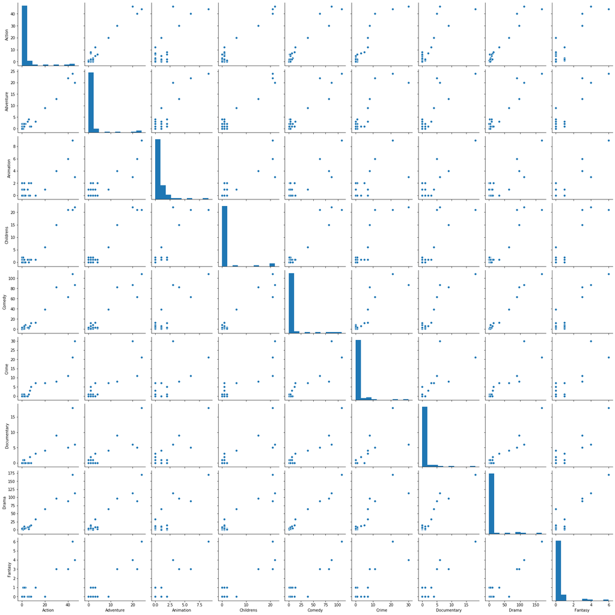

```python
# Drawing pairplot to review the correlation between various variables:
sns.pairplot(dfconsolmov[['Action','Adventure','Animation','Childrens','Comedy','Crime','Documentary','Drama','Fantasy']])
```

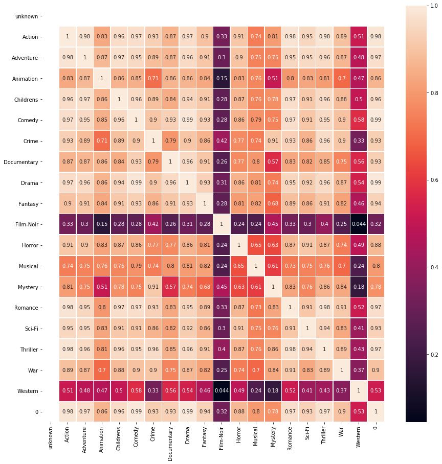

```python
plt.figure(figsize=(15,15))
sns.heatmap(dfconsolmov.corr(),annot=True,Linewidths=0.5)
plt.show()
```